# AirTimeSeriesForecasting

Dr. B

Friday, May 15, 2015

## Start the Process

```r
# Clear the environment
rm(list=ls())

# Turn off scientific notations for numbers
options(scipen = 999)
options(digits=8)

# Set locale
Sys.setlocale("LC_ALL", "English")
```

```
## [1] "LC_COLLATE=English_United States.1252;LC_CTYPE=English_United States.1252;LC_MONETARY=English_United States.1252;LC_NUMERIC=C;LC_TIME=English_United States.1252"
```

```r
# Set seed for reproducibility
set.seed(2345)

# load the libraries
library(forecast)
library(TTR)
library(fpp)
```

## Load the Data and Plot

```r
# Load the data and make it into time series
air <- scan("D:/Data/911air.txt")
airtimeseries <- ts(air, frequency=12, start=c(1990,1))
#air <- scan("D:/Data/SampleTimeSeries.txt")
#airtimeseries <- ts(air, frequency=12, start=c(2010,1))
```

Plot the timeseries data:

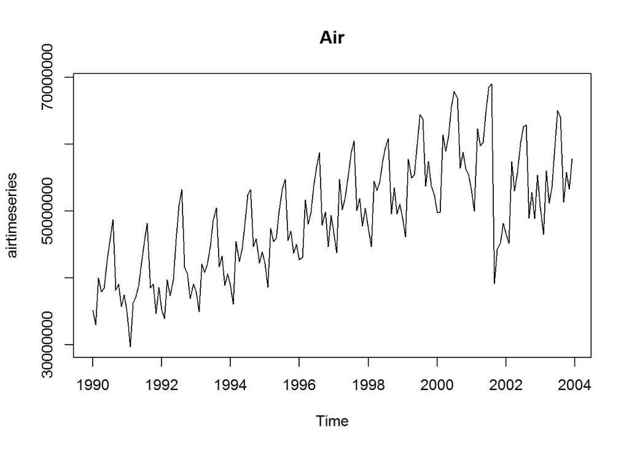

## Seasonal plots

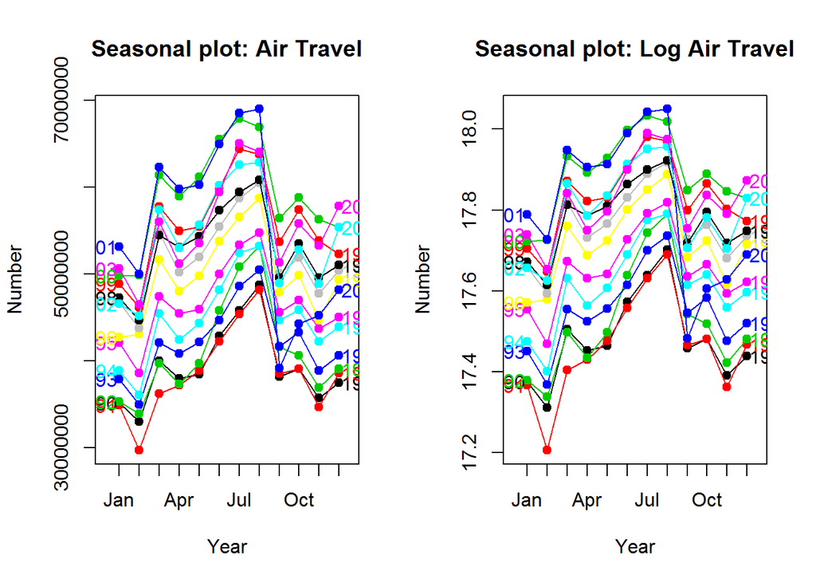

These are exactly the same data shown earlier, but now the data from each season are overlapped. A seasonal plot allows the underlying seasonal pattern to be seen more clearly, and is especially useful in identifying years in which the pattern changes.

## Seasonal subseries plots

An alternative plot that emphasises the seasonal patterns is where the data for each season are collected together in separate mini time plots.

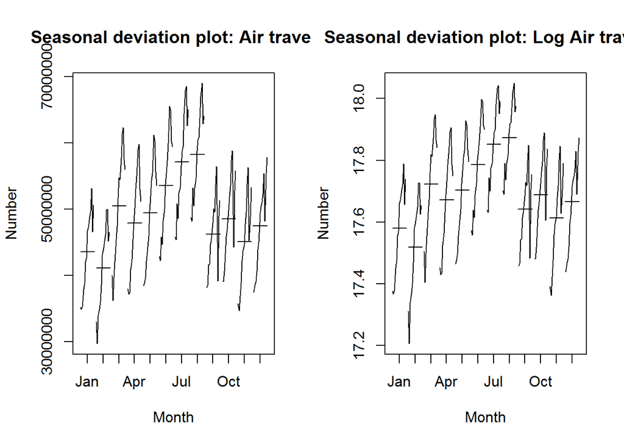

## Decomposing Time Series

Decomposing a time series means separating it into its various components, which are usually a trend component and an irregular component, and if it is a seasonal time series, a seasonal component.

### Decomposing Non-Seasonal Data

A non-seasonal time series consists of a trend component and an irregular component. Decomposing the time series involves trying to separate the time series into these components, that is, estimating the the trend component and the irregular component. To estimate the trend component of a non-seasonal time series that can be described using an additive model, it is common to use a smoothing method, such as calculating the simple moving average of the time series. The SMA() function in the “TTR” package can be used to smooth time series data using a simple moving average.

To use the SMA() function, you need to specify the order (span) of the simple moving average, using the parameter “n”. For example, to calculate a simple moving average of order 5, we set n=5 in the SMA() function.

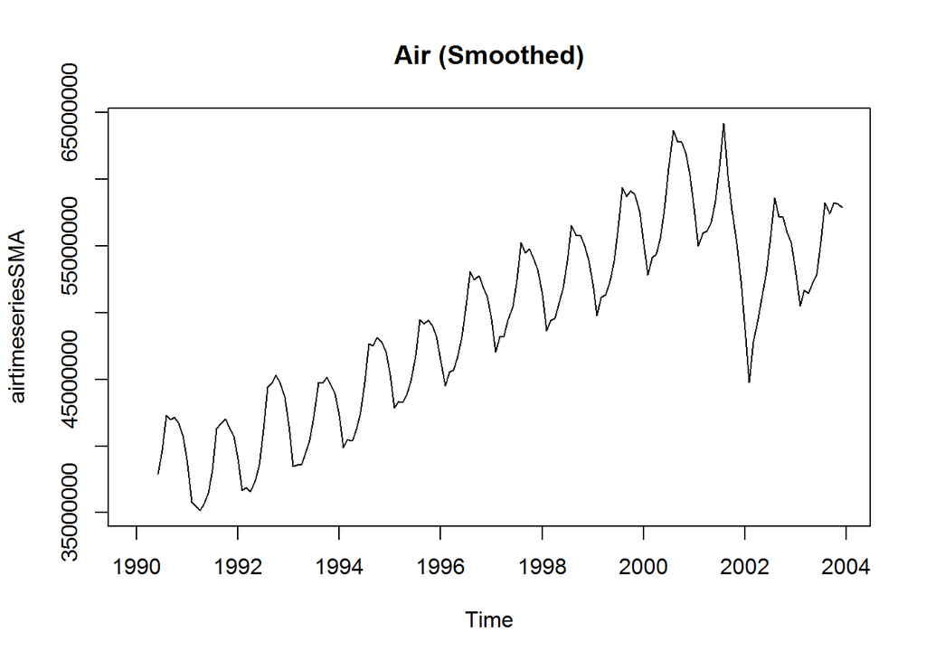

```r
#
n=6
airtimeseriesSMA <- SMA(airtimeseries,n=n)
plot.ts(airtimeseriesSMA, main="Air (Smoothed)")
```

### Decomposing Seasonal Data

A seasonal time series consists of a trend component, a seasonal component and an irregular component. Decomposing the time series means estimating these three components. To estimate the trend component and seasonal component of a seasonal time series that can be described using an additive model, we can use the “decompose()” function in R. This function estimates the trend, seasonal, and irregular components of a time series that can be described using an additive model.

The function “decompose()” returns a list object as its result, where the estimates of the seasonal component, trend component and irregular component are stored in named elements of that list objects, called “seasonal”, “trend”, and “random” respectively.

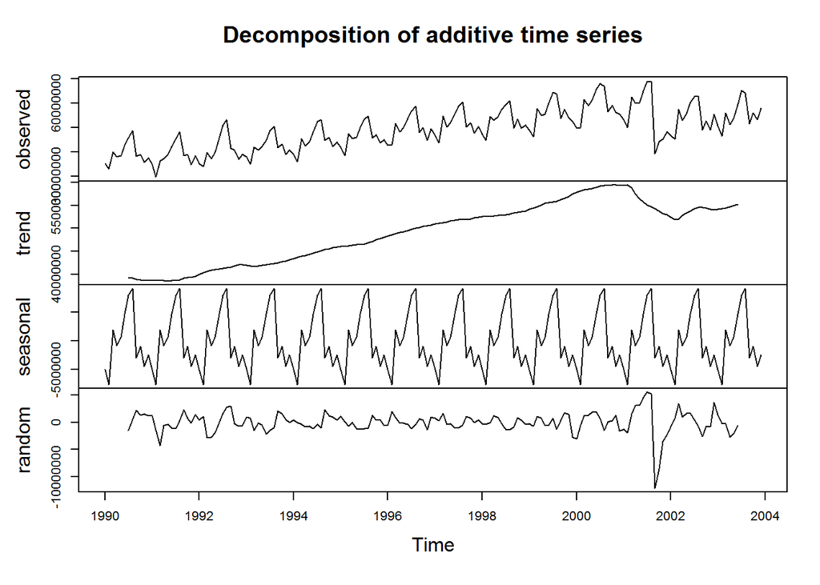

```r
#
airtimeseriescomponents <- decompose(airtimeseries)
plot(airtimeseriescomponents)
```

## Forecasting Methods

### Naive Method

This method is only appropriate for time series data. All forecasts are simply set to be the value of the last observation.

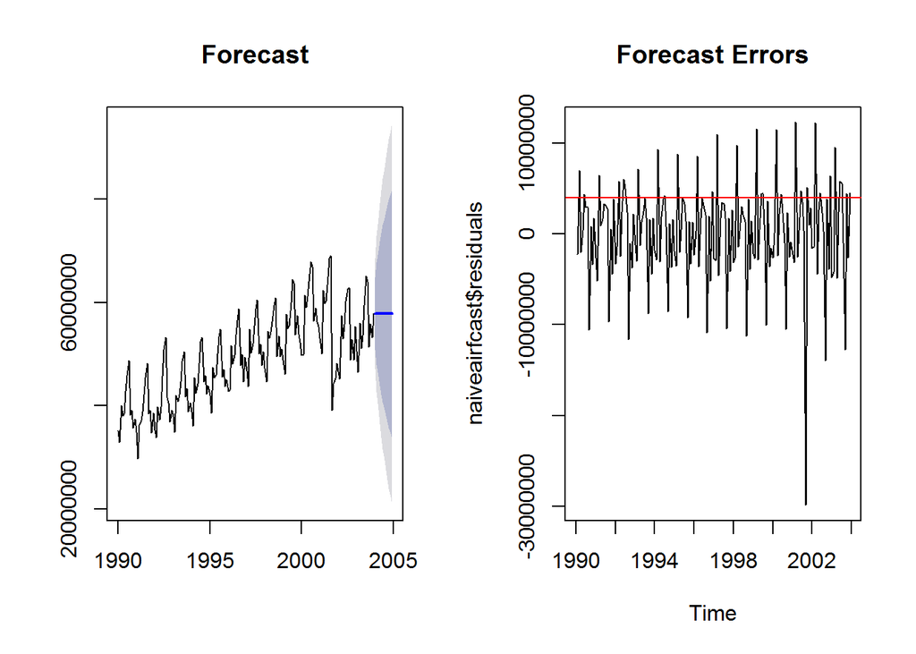

```r
# naive(y, h) or rwf(y,h)
# y contains the time series
# h is the forecast horizon
par(mfrow=c(1,2))
naiveairfcast <- naive(airtimeseries,12)
plot(naiveairfcast,main="Forecast")
plot(naiveairfcast$residuals, main="Forecast Errors")
MANE <-accuracy(naiveairfcast)[,'MAE']
abline(h=MANE,col="red")
```

```r
accuracy(naiveairfcast)
```

```
##                     ME      RMSE       MAE         MPE      MAPE      MASE
## Training set 135582.82 5457958.5 4049155.7 -0.33661789 8.4887371 1.4612963
##                     ACF1
## Training set -0.24384502
```

### Average method

The forecasts of all future values are equal to the mean of the historical data.

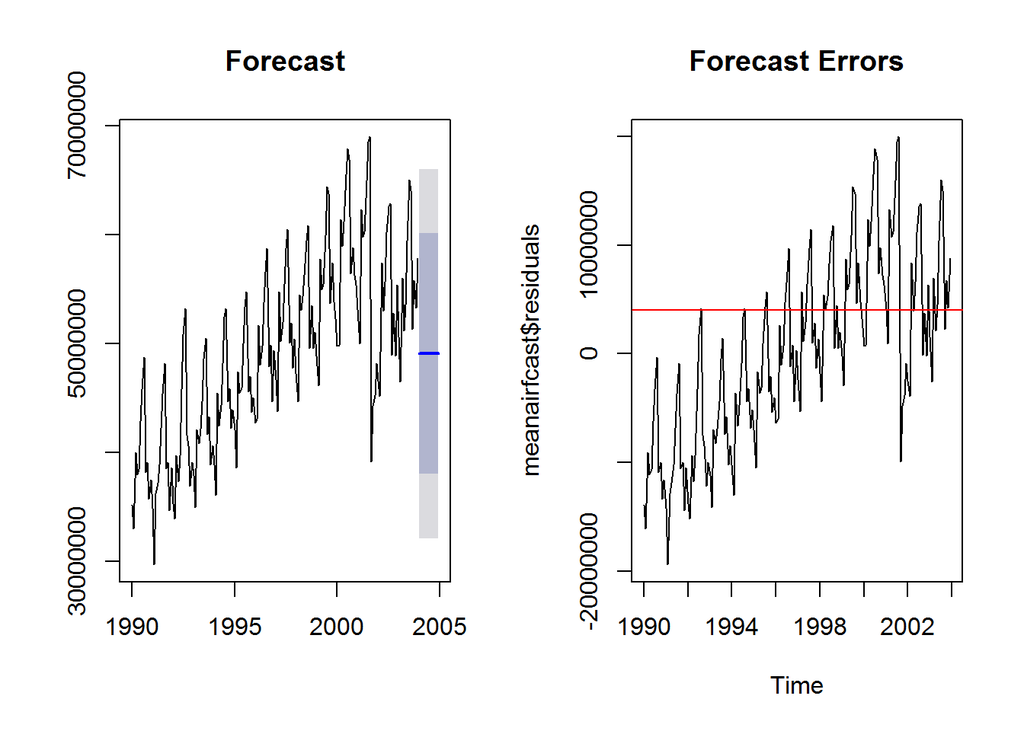

```r
# meanf(y, h)
# y contains the time series
# h is the forecast horizon
par(mfrow=c(1,2))
meanairfcast <- meanf(airtimeseries,12)
plot(meanairfcast,main="Forecast")
plot(meanairfcast$residuals,main="Forecast Errors")
abline(h=MANE,col="red")
```

```r
accuracy(meanairfcast)
```

```
##                             ME      RMSE       MAE        MPE      MAPE
## Training set 0.000000003545454 8541605.3 7044880.1 -3.1677606 15.016544
##                   MASE       ACF1
## Training set 2.5424206 0.78606545
```

### Drift method

A variation on the naïve method is to allow the forecasts to increase or decrease over time, where the amount of change over time (called the drift) is set to be the average change seen in the historical data. This is equivalent to drawing a line between the first and last observation, and extrapolating it into the future.

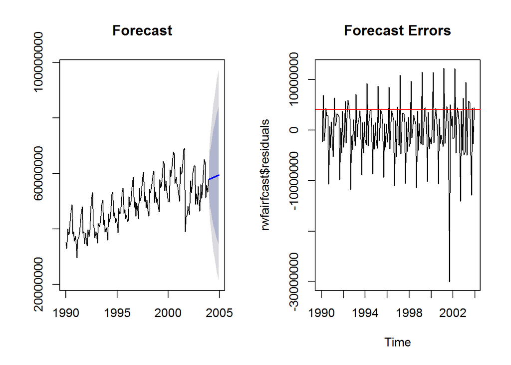

```r
#rwf(y,h, drift=TRUE)
# y contains the time series
# h is the forecast horizon
par(mfrow=c(1,2))
rwfairfcast <- rwf(airtimeseries,12, drift=TRUE)
plot(rwfairfcast, main="Forecast")
plot(rwfairfcast$residuals, main="Forecast Errors")
abline(h=MANE,col="red")
```

```r
accuracy(rwfairfcast)
```

```
##                                ME      RMSE     MAE         MPE      MAPE
## Training set -0.00000000062447976 5456274.2 4028908 -0.62117598 8.4624248
##                   MASE        ACF1
## Training set 1.4539891 -0.24384502
```

### Seasonal Naive Method

A similar method is useful for highly seasonal data. In this case, we set each forecast to be equal to the last observed value from the same season of the year (e.g., the same month of the previous year).

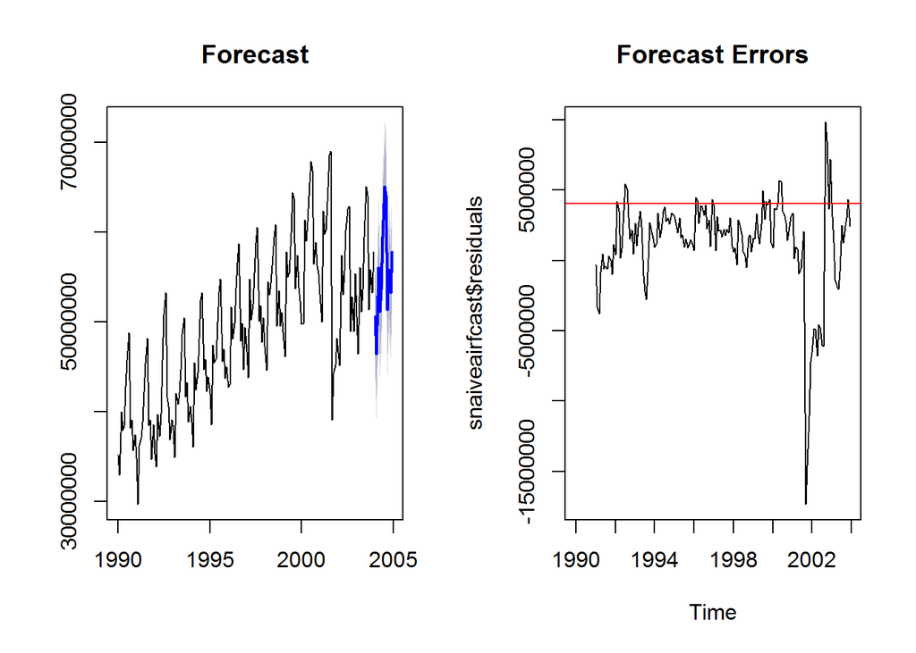

```r
# naive(y, h) or rwf(y,h)
# y contains the time series
# h is the forecast horizon
par(mfrow=c(1,2))
snaiveairfcast <- snaive(airtimeseries,12)
plot(snaiveairfcast, main="Forecast")
plot(snaiveairfcast$residuals, main="Forecast Errors")
abline(h=MANE,col="red") #MANE from naive
```

```r
accuracy(snaiveairfcast)
```

```
##                     ME      RMSE       MAE       MPE      MAPE MASE
## Training set 1233080.2 3670853.4 2770934.1 2.3513434 5.6461282    1
##                    ACF1
## Training set 0.71885486
```

### Simple exponential smoothing

The simplest of the exponentially smoothing methods is naturally called “simple exponential smoothing” (SES).

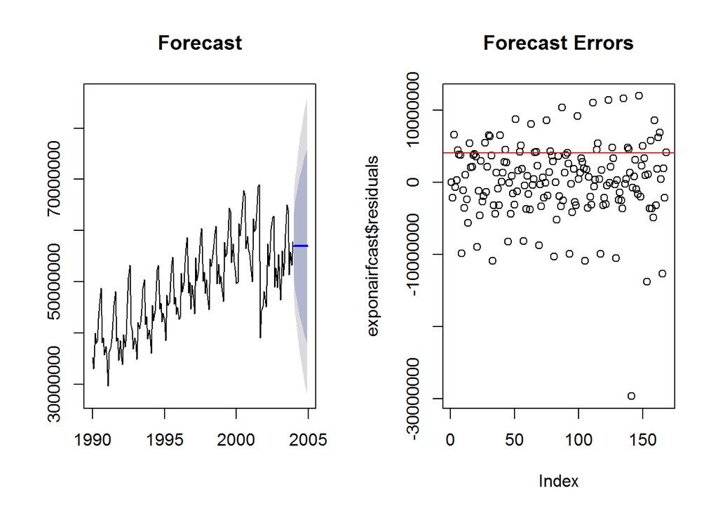

```r
par(mfrow=c(1,2))
exponairfcast<- ses(airtimeseries, alpha=0.8, initial="simple", h=12)
plot(exponairfcast, main="Forecast")
plot(exponairfcast$residuals, main="Forecast Errors")
abline(h=MANE,col="red") #MANE from naive
```

```r
accuracy(exponairfcast)
```

```
##                     ME      RMSE       MAE         MPE      MAPE      MASE
## Training set 162351.13 5271788.8 3789047.6 -0.34437844 7.9349435 1.3674261
##                      ACF1
## Training set -0.064973685
```

### Holt’s linear trend method

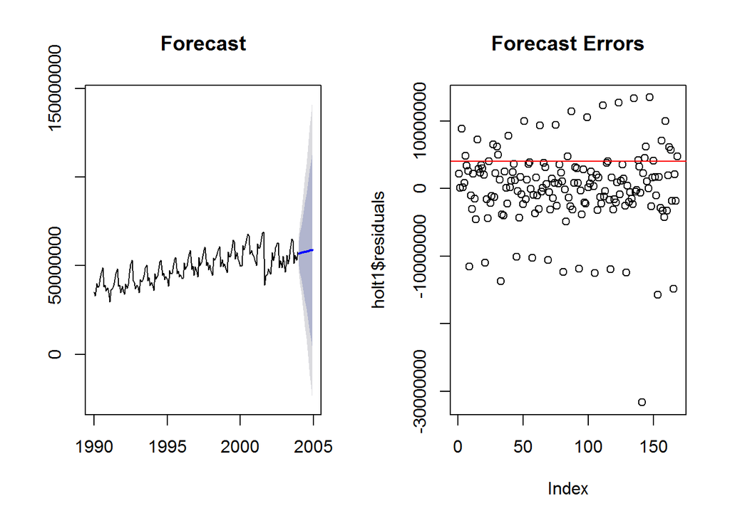

```r
par(mfrow=c(1,2))
holt1 <- holt(airtimeseries, alpha=0.8, beta=0.2, initial="simple", h=12)
holt2 <- holt(airtimeseries, alpha=0.8, beta=0.2, initial="simple", exponential=TRUE, h=12)
holt3 <- holt(airtimeseries, alpha=0.8, beta=0.2, damped=TRUE, initial="simple", h=12)
plot(holt1, main="Forecast")
plot(holt1$residuals, main="Forecast Errors")
abline(h=MANE,col="red") #MANE from naive
```

```r
accuracy(holt1)
```

```
##                     ME      RMSE       MAE         MPE      MAPE      MASE
## Training set 87840.253 5735280.7 3863914.2 -0.32193713 8.1433855 1.3944447
##                      ACF1
## Training set -0.055357563
```

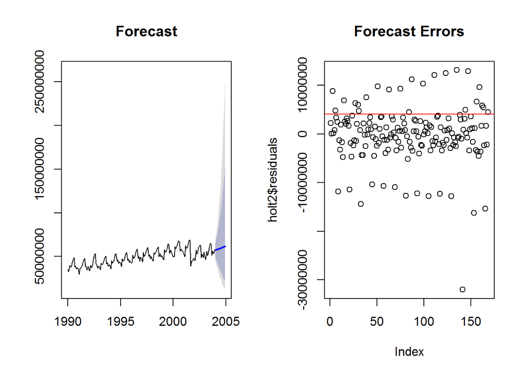

```r
plot(holt2, main="Forecast")
plot(holt2$residuals, main="Forecast Errors")
abline(h=MANE,col="red") #MANE from naive
```

```r
accuracy(holt2)
```

```
##                     ME      RMSE       MAE         MPE      MAPE     MASE
## Training set -234532.3 5759568.1 3847852.1 -0.98700757 8.1351565 1.388648
##                      ACF1
## Training set -0.046444452
```

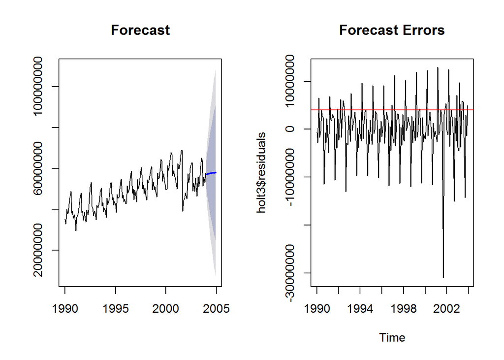

```r
plot(holt3, main="Forecast")
plot(holt3$residuals, main="Forecast Errors")
abline(h=MANE,col="red") #MANE from naive
```

```r
accuracy(holt3)
```

```
##                     ME      RMSE       MAE         MPE      MAPE      MASE
## Training set 72140.519 5546752.8 3794161.6 -0.41015765 7.9859113 1.3692717
##                     ACF1
## Training set -0.12818391
```

### Holt-Winters exponential smoothing

If you have a time series that can be described using an additive model with increasing or decreasing trend and seasonality, you can use Holt-Winters exponential smoothing to make short-term forecasts. Holt-Winters exponential smoothing estimates the level, slope, and seasonal component at the current time point.

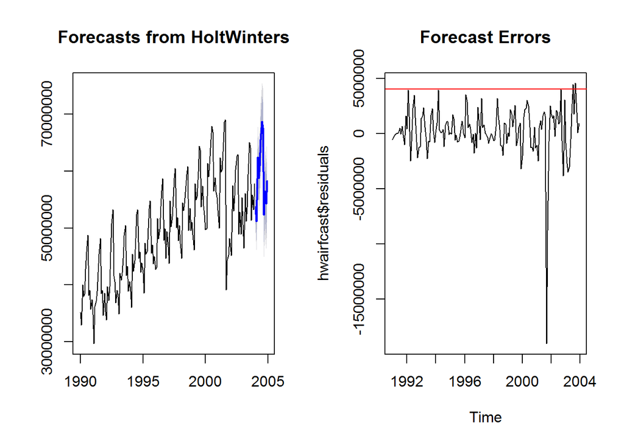

```r
par(mfrow=c(1,2))
airHWforecast <- HoltWinters(airtimeseries)
hwairfcast <- forecast.HoltWinters(airHWforecast, h=12)
plot(hwairfcast)
plot(hwairfcast$residuals,main="Forecast Errors")
abline(h=MANE,col="red") #MANE from naive
```

```r
accuracy(hwairfcast)
```

```
##                     ME      RMSE       MAE        MPE      MAPE       MASE
## Training set 252762.99 2344940.6 1426766.2 0.58119644 2.9345077 0.50741727
##                    ACF1
## Training set 0.35271844
```

### ARIMA Model

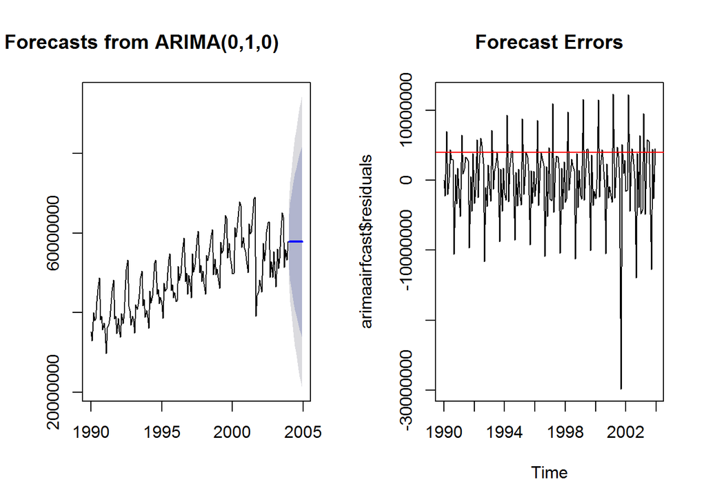

```r
par(mfrow=c(1,2))
# fit an ARIMA(0,1,1) model
arimaairtimeseries <- arima(airtimeseries, order=c(0,1,0))
arimaairfcast<- forecast.Arima(arimaairtimeseries, h=12)
plot(arimaairfcast)
plot(arimaairfcast$residuals,main="Forecast Errors")
abline(h=MANE,col="red") #MANE from naive
```

```r
accuracy(arimaairfcast)
```

```
##                     ME    RMSE       MAE         MPE      MAPE      MASE
## Training set 134985.03 5441691 4025262.8 -0.33401898 8.4388041 1.4526736
##                     ACF1
## Training set -0.24379811
```

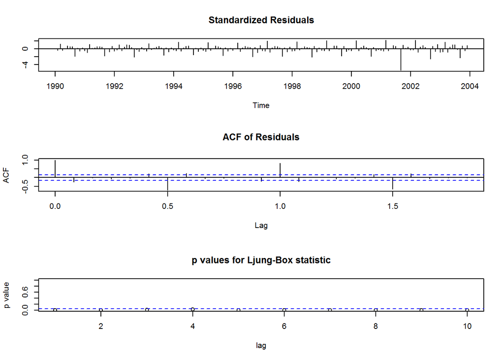

```r
tsdiag(arimaairtimeseries)
```

### Automated forecasting using an exponential model

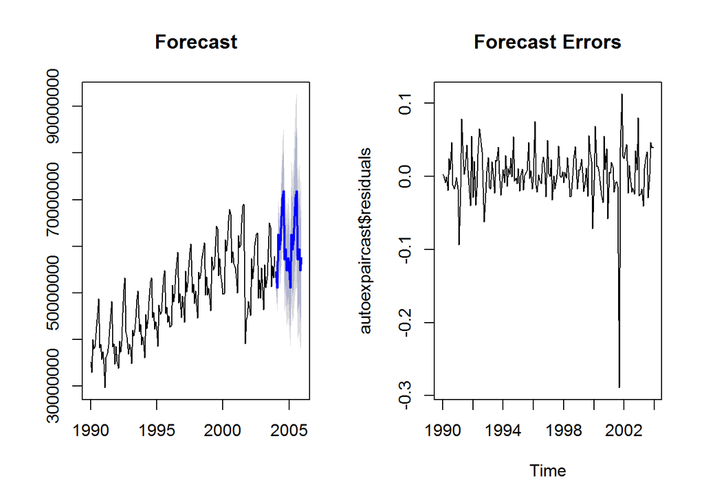

```r
par(mfrow=c(1,2))
# Automated forecasting using an exponential model
autoexpaircast<-ets(airtimeseries)
plot(forecast(autoexpaircast), main="Forecast")
plot(autoexpaircast$residuals, main="Forecast Errors")
abline(h=MANE,col="red") #MANE from naive
```

```r
accuracy(autoexpaircast)
```

```
##                     ME      RMSE       MAE        MPE      MAPE       MASE
## Training set 140705.79 1853211.9 1144660.7 0.20720425 2.3985129 0.28269119
##                     ACF1
## Training set 0.046441684
```

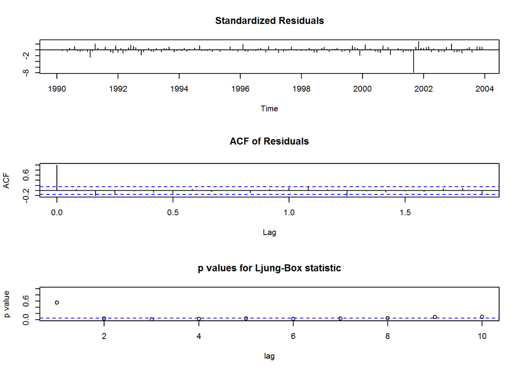

```r
tsdiag(autoexpaircast)
```

### Automated ARIMA Model

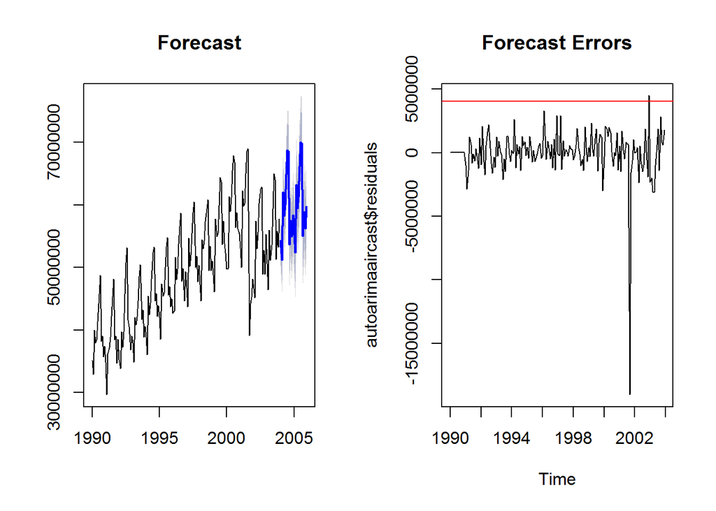

```r
par(mfrow=c(1,2))
# Automated forecasting using an ARIMA model
autoarimaaircast<-auto.arima(airtimeseries)
plot(forecast(autoarimaaircast), main="Forecast")
plot(autoarimaaircast$residuals, main="Forecast Errors")
abline(h=MANE,col="red") #MANE from naive
```

```r
accuracy(autoarimaaircast)
```

```
##                     ME      RMSE       MAE         MPE      MAPE      MASE
## Training set -332.2908 1932945.8 1054067.7 -0.13064969 2.2206098 0.2603179
##                     ACF1
## Training set 0.018238102
```

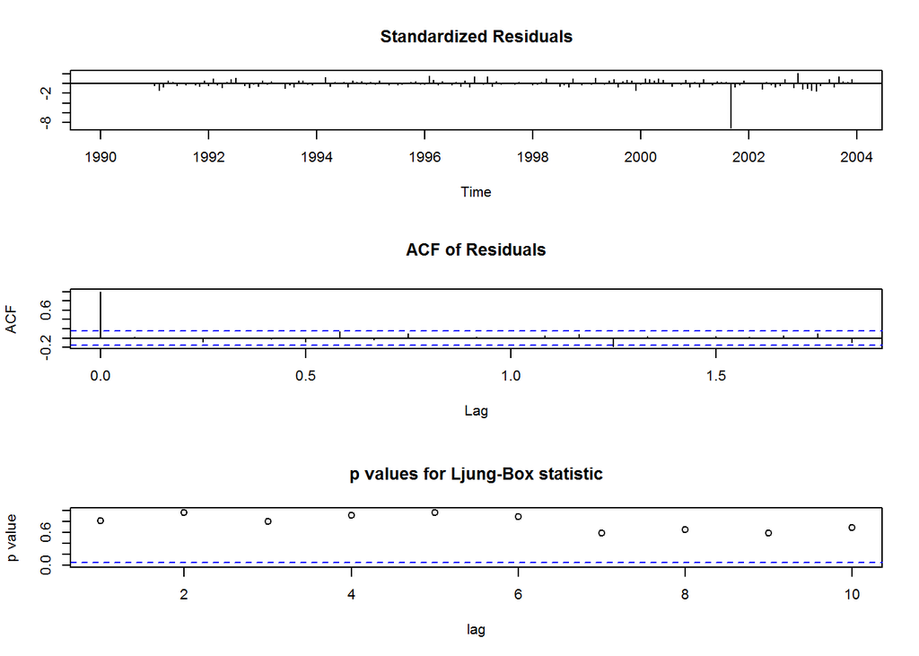

```r
tsdiag(autoarimaaircast)
```

### Summary

A summary of Training Set MASE for the all methods covered:

```r
accuracy(naiveairfcast)[,'MASE']
```

```
## [1] 1.4612963
```

```r
accuracy(meanairfcast)[,'MASE']
```

```
## [1] 2.5424206
```

```r
accuracy(rwfairfcast)[,'MASE']
```

```
## [1] 1.4539891
```

```r
accuracy(snaiveairfcast)[,'MASE']
```

```
## [1] 1
```

```r
accuracy(exponairfcast)[,'MASE']
```

```
## [1] 1.3674261
```

```r
accuracy(holt1)[,'MASE']
```

```
## [1] 1.3944447
```

```r
accuracy(holt2)[,'MASE']
```

```
## [1] 1.388648
```

```r
accuracy(holt3)[,'MASE']
```

```
## [1] 1.3692717
```

```r
accuracy(hwairfcast)[,'MASE']
```

```
## [1] 0.50741727
```

```r
accuracy(arimaairfcast)[,'MASE']
```

```
## [1] 1.4526736
```

```r
accuracy(autoexpaircast)[,'MASE']
```

```
## [1] 0.28269119
```

```r
accuracy(autoarimaaircast)[,'MASE']
```

```
## [1] 0.2603179
```